# Risk Factor Analysis

## Outcome Variable

**Outcome Variable:** ever_wasted

## Predictor Variables

**Intervention Variable:** vagbrth

**Adjustment Set:**

- arm
- sex
- W_mage
- meducyrs
- feducyrs
- hhwealth_quart
- W_mhtcm
- W_mwtkg
- W_mbmi
- single
- brthmon
- W_parity
- delta_W_mage
- delta_meducyrs
- delta_feducyrs
- delta_hhwealth_quart
- delta_W_mhtcm
- delta_W_mwtkg
- delta_W_mbmi
- delta_single
- delta_brthmon
- delta_W_parity

## Stratifying Variables

The analysis was stratified on these variable(s):

- agecat
- studyid
- country

## Data Summary

| agecat | studyid | country | vagbrth | ever_wasted | n_cell | n |
| --- | --- | --- | --- | --- | --- | --- |
| 0-24 months (no birth wast) | CMC-V-BCS-2002 | INDIA | 0 | 0 | 17 | 368 |
| 0-24 months (no birth wast) | CMC-V-BCS-2002 | INDIA | 0 | 1 | 8 | 368 |
| 0-24 months (no birth wast) | CMC-V-BCS-2002 | INDIA | 1 | 0 | 185 | 368 |
| 0-24 months (no birth wast) | CMC-V-BCS-2002 | INDIA | 1 | 1 | 158 | 368 |
| 0-24 months (no birth wast) | IRC | INDIA | 0 | 0 | 38 | 409 |
| 0-24 months (no birth wast) | IRC | INDIA | 0 | 1 | 32 | 409 |
| 0-24 months (no birth wast) | IRC | INDIA | 1 | 0 | 158 | 409 |
| 0-24 months (no birth wast) | IRC | INDIA | 1 | 1 | 181 | 409 |
| 0-24 months (no birth wast) | JiVitA-3 | BANGLADESH | 0 | 0 | 1301 | 26404 |
| 0-24 months (no birth wast) | JiVitA-3 | BANGLADESH | 0 | 1 | 189 | 26404 |
| 0-24 months (no birth wast) | JiVitA-3 | BANGLADESH | 1 | 0 | 20624 | 26404 |
| 0-24 months (no birth wast) | JiVitA-3 | BANGLADESH | 1 | 1 | 4290 | 26404 |
| 0-24 months (no birth wast) | JiVitA-4 | BANGLADESH | 0 | 0 | 291 | 4499 |
| 0-24 months (no birth wast) | JiVitA-4 | BANGLADESH | 0 | 1 | 79 | 4499 |
| 0-24 months (no birth wast) | JiVitA-4 | BANGLADESH | 1 | 0 | 3007 | 4499 |
| 0-24 months (no birth wast) | JiVitA-4 | BANGLADESH | 1 | 1 | 1122 | 4499 |
| 0-24 months (no birth wast) | NIH-Crypto | BANGLADESH | 0 | 0 | 181 | 496 |
| 0-24 months (no birth wast) | NIH-Crypto | BANGLADESH | 0 | 1 | 21 | 496 |
| 0-24 months (no birth wast) | NIH-Crypto | BANGLADESH | 1 | 0 | 245 | 496 |
| 0-24 months (no birth wast) | NIH-Crypto | BANGLADESH | 1 | 1 | 49 | 496 |
| 0-24 months (no birth wast) | PROBIT | BELARUS | 0 | 0 | 1805 | 16879 |
| 0-24 months (no birth wast) | PROBIT | BELARUS | 0 | 1 | 147 | 16879 |
| 0-24 months (no birth wast) | PROBIT | BELARUS | 1 | 0 | 13926 | 16879 |
| 0-24 months (no birth wast) | PROBIT | BELARUS | 1 | 1 | 1001 | 16879 |
| 0-24 months (no birth wast) | PROVIDE | BANGLADESH | 0 | 0 | 132 | 687 |
| 0-24 months (no birth wast) | PROVIDE | BANGLADESH | 0 | 1 | 27 | 687 |
| 0-24 months (no birth wast) | PROVIDE | BANGLADESH | 1 | 0 | 433 | 687 |
| 0-24 months (no birth wast) | PROVIDE | BANGLADESH | 1 | 1 | 95 | 687 |
| 0-24 months (no birth wast) | TanzaniaChild2 | TANZANIA, UNITED REPUBLIC OF | 0 | 0 | 174 | 2355 |
| 0-24 months (no birth wast) | TanzaniaChild2 | TANZANIA, UNITED REPUBLIC OF | 0 | 1 | 38 | 2355 |

[output cut: 78 more lines]

The following strata were considered:

- agecat: 0-24 months (no birth wast), studyid: CMC-V-BCS-2002, country: INDIA
- agecat: 0-24 months (no birth wast), studyid: IRC, country: INDIA
- agecat: 0-24 months (no birth wast), studyid: JiVitA-3, country: BANGLADESH
- agecat: 0-24 months (no birth wast), studyid: JiVitA-4, country: BANGLADESH
- agecat: 0-24 months (no birth wast), studyid: NIH-Crypto, country: BANGLADESH
- agecat: 0-24 months (no birth wast), studyid: PROBIT, country: BELARUS
- agecat: 0-24 months (no birth wast), studyid: PROVIDE, country: BANGLADESH
- agecat: 0-24 months (no birth wast), studyid: TanzaniaChild2, country: TANZANIA, UNITED REPUBLIC OF
- agecat: 0-24 months (no birth wast), studyid: ZVITAMBO, country: ZIMBABWE
- agecat: 0-6 months (no birth wast), studyid: CMC-V-BCS-2002, country: INDIA
- agecat: 0-6 months (no birth wast), studyid: IRC, country: INDIA
- agecat: 0-6 months (no birth wast), studyid: JiVitA-3, country: BANGLADESH
- agecat: 0-6 months (no birth wast), studyid: JiVitA-4, country: BANGLADESH
- agecat: 0-6 months (no birth wast), studyid: NIH-Crypto, country: BANGLADESH
- agecat: 0-6 months (no birth wast), studyid: PROBIT, country: BELARUS
- agecat: 0-6 months (no birth wast), studyid: PROVIDE, country: BANGLADESH
- agecat: 0-6 months (no birth wast), studyid: TanzaniaChild2, country: TANZANIA, UNITED REPUBLIC OF
- agecat: 0-6 months (no birth wast), studyid: ZVITAMBO, country: ZIMBABWE
- agecat: 6-24 months, studyid: CMC-V-BCS-2002, country: INDIA
- agecat: 6-24 months, studyid: IRC, country: INDIA
- agecat: 6-24 months, studyid: JiVitA-3, country: BANGLADESH
- agecat: 6-24 months, studyid: JiVitA-4, country: BANGLADESH
- agecat: 6-24 months, studyid: NIH-Crypto, country: BANGLADESH
- agecat: 6-24 months, studyid: PROBIT, country: BELARUS
- agecat: 6-24 months, studyid: PROVIDE, country: BANGLADESH
- agecat: 6-24 months, studyid: TanzaniaChild2, country: TANZANIA, UNITED REPUBLIC OF
- agecat: 6-24 months, studyid: ZVITAMBO, country: ZIMBABWE

### Dropped Strata

Some strata were dropped due to rare outcomes:

- agecat: 0-6 months (no birth wast), studyid: NIH-Crypto, country: BANGLADESH
- agecat: 6-24 months, studyid: CMC-V-BCS-2002, country: INDIA

## Methods Detail

We’re interested in the causal parameters $E[Y_a]$ for all values of $a \in \mathcal{A}$. These parameters represent the mean outcome if, possibly contrary to fact, we intervened to set all units to have $A=a$. Under the randomization and positivity assumptions, these are identified by the statistical parameters $\psi_a=E_W[E_{Y|A,W}(Y|A=a,W)]$. In addition, we’re interested in the mean of $Y$, $E[Y]$ under no intervention (the observed mean). We will estimate these parameters by using SuperLearner to fit the relevant likelihood factors – $E_{Y|A,W}(Y|A=a,W)$ and $p(A=a|W)$, and then updating our likelihood fit using a joint TMLE.

For unadjusted analyses ($W=\{\}$), initial likelihoods were estimated using Lrnr_glm to estimate the simple $E(Y|A)$ and Lrnr_mean to estimate $p(A)$. For adjusted analyses, a small library containing Lrnr_glmnet, Lrnr_xgboost, and Lrnr_mean was used.

Having estimated these parameters, we will then use the delta method to estimate relative risks and attributable risks relative to a prespecified baseline level of $A$.

# Results Detail

## Results Plots

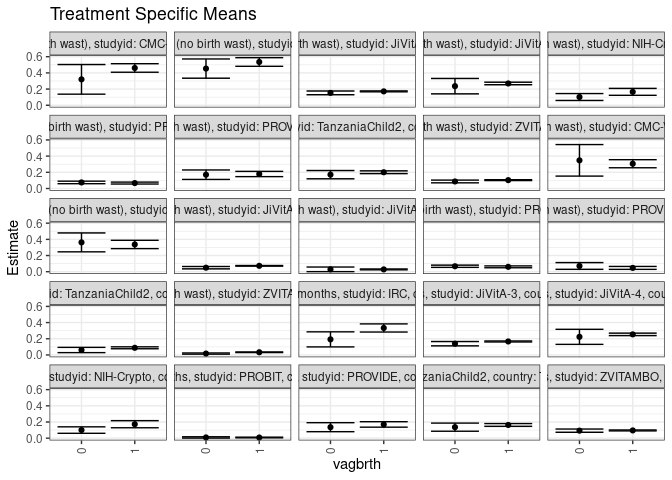

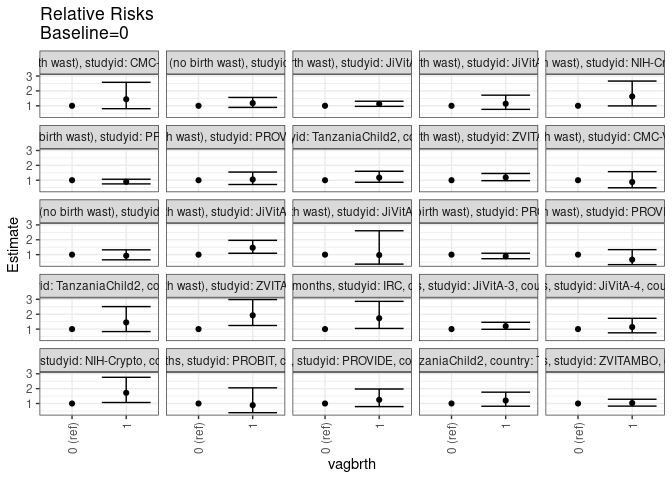

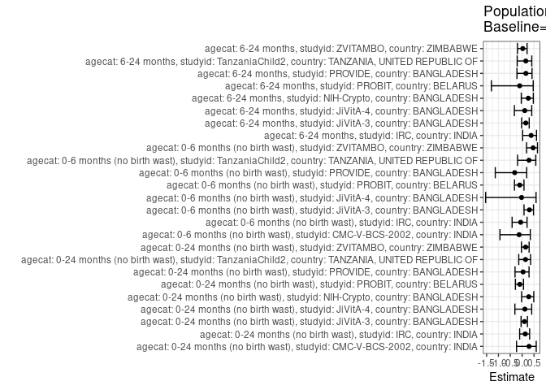

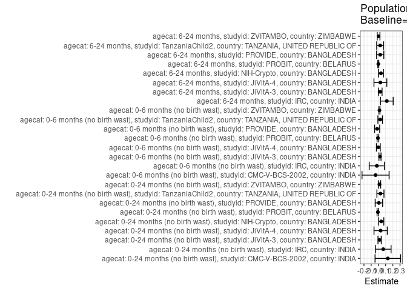

## Results Table

### Parameter: TSM

| agecat | studyid | country | intervention_level | baseline_level | estimate | ci_lower | ci_upper |
| --- | --- | --- | --- | --- | --- | --- | --- |
| 0-24 months (no birth wast) | CMC-V-BCS-2002 | INDIA | 0 | NA | 0.3200000 | 0.1368958 | 0.5031042 |
| 0-24 months (no birth wast) | CMC-V-BCS-2002 | INDIA | 1 | NA | 0.4606414 | 0.4078197 | 0.5134631 |
| 0-24 months (no birth wast) | IRC | INDIA | 0 | NA | 0.4530521 | 0.3342463 | 0.5718580 |
| 0-24 months (no birth wast) | IRC | INDIA | 1 | NA | 0.5347416 | 0.4815861 | 0.5878971 |
| 0-24 months (no birth wast) | JiVitA-3 | BANGLADESH | 0 | NA | 0.1530000 | 0.1299218 | 0.1760782 |
| 0-24 months (no birth wast) | JiVitA-3 | BANGLADESH | 1 | NA | 0.1714458 | 0.1659960 | 0.1768957 |
| 0-24 months (no birth wast) | JiVitA-4 | BANGLADESH | 0 | NA | 0.2359412 | 0.1407688 | 0.3311137 |
| 0-24 months (no birth wast) | JiVitA-4 | BANGLADESH | 1 | NA | 0.2692086 | 0.2536427 | 0.2847744 |
| 0-24 months (no birth wast) | NIH-Crypto | BANGLADESH | 0 | NA | 0.1018137 | 0.0592090 | 0.1444185 |
| 0-24 months (no birth wast) | NIH-Crypto | BANGLADESH | 1 | NA | 0.1655496 | 0.1228193 | 0.2082799 |
| 0-24 months (no birth wast) | PROBIT | BELARUS | 0 | NA | 0.0748557 | 0.0592484 | 0.0904631 |
| 0-24 months (no birth wast) | PROBIT | BELARUS | 1 | NA | 0.0669884 | 0.0550230 | 0.0789537 |
| 0-24 months (no birth wast) | PROVIDE | BANGLADESH | 0 | NA | 0.1705184 | 0.1120519 | 0.2289848 |
| 0-24 months (no birth wast) | PROVIDE | BANGLADESH | 1 | NA | 0.1789680 | 0.1462574 | 0.2116785 |
| 0-24 months (no birth wast) | TanzaniaChild2 | TANZANIA, UNITED REPUBLIC OF | 0 | NA | 0.1708811 | 0.1198598 | 0.2219025 |
| 0-24 months (no birth wast) | TanzaniaChild2 | TANZANIA, UNITED REPUBLIC OF | 1 | NA | 0.2007913 | 0.1838212 | 0.2177614 |
| 0-24 months (no birth wast) | ZVITAMBO | ZIMBABWE | 0 | NA | 0.0867884 | 0.0697619 | 0.1038148 |
| 0-24 months (no birth wast) | ZVITAMBO | ZIMBABWE | 1 | NA | 0.1030559 | 0.0977000 | 0.1084119 |
| 0-6 months (no birth wast) | CMC-V-BCS-2002 | INDIA | 0 | NA | 0.3478261 | 0.1529008 | 0.5427514 |
| 0-6 months (no birth wast) | CMC-V-BCS-2002 | INDIA | 1 | NA | 0.3058104 | 0.2558000 | 0.3558208 |
| 0-6 months (no birth wast) | IRC | INDIA | 0 | NA | 0.3626179 | 0.2458882 | 0.4793476 |
| 0-6 months (no birth wast) | IRC | INDIA | 1 | NA | 0.3365352 | 0.2850057 | 0.3880646 |
| 0-6 months (no birth wast) | JiVitA-3 | BANGLADESH | 0 | NA | 0.0497491 | 0.0352576 | 0.0642406 |
| 0-6 months (no birth wast) | JiVitA-3 | BANGLADESH | 1 | NA | 0.0728729 | 0.0691019 | 0.0766440 |
| 0-6 months (no birth wast) | JiVitA-4 | BANGLADESH | 0 | NA | 0.0294892 | 0.0011431 | 0.0578354 |
| 0-6 months (no birth wast) | JiVitA-4 | BANGLADESH | 1 | NA | 0.0286618 | 0.0233249 | 0.0339988 |
| 0-6 months (no birth wast) | PROBIT | BELARUS | 0 | NA | 0.0676399 | 0.0539411 | 0.0813387 |
| 0-6 months (no birth wast) | PROBIT | BELARUS | 1 | NA | 0.0603961 | 0.0489031 | 0.0718891 |
| 0-6 months (no birth wast) | PROVIDE | BANGLADESH | 0 | NA | 0.0711886 | 0.0295591 | 0.1128180 |
| 0-6 months (no birth wast) | PROVIDE | BANGLADESH | 1 | NA | 0.0471926 | 0.0289502 | 0.0654350 |
| 0-6 months (no birth wast) | TanzaniaChild2 | TANZANIA, UNITED REPUBLIC OF | 0 | NA | 0.0611480 | 0.0284715 | 0.0938245 |
| 0-6 months (no birth wast) | TanzaniaChild2 | TANZANIA, UNITED REPUBLIC OF | 1 | NA | 0.0884897 | 0.0764387 | 0.1005408 |
| 0-6 months (no birth wast) | ZVITAMBO | ZIMBABWE | 0 | NA | 0.0172512 | 0.0098691 | 0.0246334 |
| 0-6 months (no birth wast) | ZVITAMBO | ZIMBABWE | 1 | NA | 0.0332088 | 0.0300198 | 0.0363979 |
| 6-24 months | IRC | INDIA | 0 | NA | 0.1926847 | 0.0995480 | 0.2858213 |
| 6-24 months | IRC | INDIA | 1 | NA | 0.3333723 | 0.2831530 | 0.3835915 |
| 6-24 months | JiVitA-3 | BANGLADESH | 0 | NA | 0.1390023 | 0.1121785 | 0.1658261 |
| 6-24 months | JiVitA-3 | BANGLADESH | 1 | NA | 0.1665675 | 0.1602059 | 0.1729292 |
| 6-24 months | JiVitA-4 | BANGLADESH | 0 | NA | 0.2238503 | 0.1310034 | 0.3166972 |
| 6-24 months | JiVitA-4 | BANGLADESH | 1 | NA | 0.2543090 | 0.2390906 | 0.2695274 |
| 6-24 months | NIH-Crypto | BANGLADESH | 0 | NA | 0.1004180 | 0.0604300 | 0.1404061 |
| 6-24 months | NIH-Crypto | BANGLADESH | 1 | NA | 0.1725877 | 0.1287734 | 0.2164020 |
| 6-24 months | PROBIT | BELARUS | 0 | NA | 0.0092619 | 0.0015393 | 0.0169844 |
| 6-24 months | PROBIT | BELARUS | 1 | NA | 0.0082178 | 0.0041290 | 0.0123065 |
| 6-24 months | PROVIDE | BANGLADESH | 0 | NA | 0.1357174 | 0.0800106 | 0.1914242 |
| 6-24 months | PROVIDE | BANGLADESH | 1 | NA | 0.1698045 | 0.1359249 | 0.2036842 |
| 6-24 months | TanzaniaChild2 | TANZANIA, UNITED REPUBLIC OF | 0 | NA | 0.1362076 | 0.0858221 | 0.1865931 |
| 6-24 months | TanzaniaChild2 | TANZANIA, UNITED REPUBLIC OF | 1 | NA | 0.1634659 | 0.1463559 | 0.1805758 |
| 6-24 months | ZVITAMBO | ZIMBABWE | 0 | NA | 0.0929933 | 0.0732097 | 0.1127769 |
| 6-24 months | ZVITAMBO | ZIMBABWE | 1 | NA | 0.0959672 | 0.0901329 | 0.1018016 |

### Parameter: E(Y)

| agecat | studyid | country | intervention_level | baseline_level | estimate | ci_lower | ci_upper |
| --- | --- | --- | --- | --- | --- | --- | --- |
| 0-24 months (no birth wast) | CMC-V-BCS-2002 | INDIA | NA | NA | 0.4510870 | 0.4001777 | 0.5019962 |
| 0-24 months (no birth wast) | IRC | INDIA | NA | NA | 0.5207824 | 0.4723080 | 0.5692568 |
| 0-24 months (no birth wast) | JiVitA-3 | BANGLADESH | NA | NA | 0.1696334 | 0.1643208 | 0.1749460 |
| 0-24 months (no birth wast) | JiVitA-4 | BANGLADESH | NA | NA | 0.2669482 | 0.2519234 | 0.2819730 |
| 0-24 months (no birth wast) | NIH-Crypto | BANGLADESH | NA | NA | 0.1411290 | 0.1104588 | 0.1717993 |
| 0-24 months (no birth wast) | PROBIT | BELARUS | NA | NA | 0.0680135 | 0.0562135 | 0.0798135 |
| 0-24 months (no birth wast) | PROVIDE | BANGLADESH | NA | NA | 0.1775837 | 0.1489858 | 0.2061816 |
| 0-24 months (no birth wast) | TanzaniaChild2 | TANZANIA, UNITED REPUBLIC OF | NA | NA | 0.1991507 | 0.1830179 | 0.2152836 |
| 0-24 months (no birth wast) | ZVITAMBO | ZIMBABWE | NA | NA | 0.1017601 | 0.0966641 | 0.1068561 |
| 0-6 months (no birth wast) | CMC-V-BCS-2002 | INDIA | NA | NA | 0.3085714 | 0.2601110 | 0.3570318 |
| 0-6 months (no birth wast) | IRC | INDIA | NA | NA | 0.3410256 | 0.2939169 | 0.3881343 |
| 0-6 months (no birth wast) | JiVitA-3 | BANGLADESH | NA | NA | 0.0718055 | 0.0681632 | 0.0754477 |
| 0-6 months (no birth wast) | JiVitA-4 | BANGLADESH | NA | NA | 0.0287671 | 0.0234680 | 0.0340662 |
| 0-6 months (no birth wast) | PROBIT | BELARUS | NA | NA | 0.0612233 | 0.0502388 | 0.0722078 |
| 0-6 months (no birth wast) | PROVIDE | BANGLADESH | NA | NA | 0.0541728 | 0.0371844 | 0.0711612 |
| 0-6 months (no birth wast) | TanzaniaChild2 | TANZANIA, UNITED REPUBLIC OF | NA | NA | 0.0860673 | 0.0747182 | 0.0974164 |
| 0-6 months (no birth wast) | ZVITAMBO | ZIMBABWE | NA | NA | 0.0321170 | 0.0291164 | 0.0351176 |
| 6-24 months | IRC | INDIA | NA | NA | 0.3097561 | 0.2649438 | 0.3545684 |
| 6-24 months | JiVitA-3 | BANGLADESH | NA | NA | 0.1640716 | 0.1579211 | 0.1702221 |
| 6-24 months | JiVitA-4 | BANGLADESH | NA | NA | 0.2516630 | 0.2368610 | 0.2664649 |
| 6-24 months | NIH-Crypto | BANGLADESH | NA | NA | 0.1355932 | 0.1046749 | 0.1665115 |
| 6-24 months | PROBIT | BELARUS | NA | NA | 0.0083745 | 0.0044130 | 0.0123360 |
| 6-24 months | PROVIDE | BANGLADESH | NA | NA | 0.1609756 | 0.1319065 | 0.1900447 |
| 6-24 months | TanzaniaChild2 | TANZANIA, UNITED REPUBLIC OF | NA | NA | 0.1608216 | 0.1447012 | 0.1769421 |
| 6-24 months | ZVITAMBO | ZIMBABWE | NA | NA | 0.0954957 | 0.0899327 | 0.1010586 |

### Parameter: RR

| agecat | studyid | country | intervention_level | baseline_level | estimate | ci_lower | ci_upper |
| --- | --- | --- | --- | --- | --- | --- | --- |
| 0-24 months (no birth wast) | CMC-V-BCS-2002 | INDIA | 0 | 0 | 1.0000000 | 1.0000000 | 1.000000 |
| 0-24 months (no birth wast) | CMC-V-BCS-2002 | INDIA | 1 | 0 | 1.4395044 | 0.8030978 | 2.580225 |
| 0-24 months (no birth wast) | IRC | INDIA | 0 | 0 | 1.0000000 | 1.0000000 | 1.000000 |
| 0-24 months (no birth wast) | IRC | INDIA | 1 | 0 | 1.1803093 | 0.8915715 | 1.562556 |
| 0-24 months (no birth wast) | JiVitA-3 | BANGLADESH | 0 | 0 | 1.0000000 | 1.0000000 | 1.000000 |
| 0-24 months (no birth wast) | JiVitA-3 | BANGLADESH | 1 | 0 | 1.1205611 | 0.9614185 | 1.306046 |
| 0-24 months (no birth wast) | JiVitA-4 | BANGLADESH | 0 | 0 | 1.0000000 | 1.0000000 | 1.000000 |
| 0-24 months (no birth wast) | JiVitA-4 | BANGLADESH | 1 | 0 | 1.1409984 | 0.7596311 | 1.713828 |
| 0-24 months (no birth wast) | NIH-Crypto | BANGLADESH | 0 | 0 | 1.0000000 | 1.0000000 | 1.000000 |
| 0-24 months (no birth wast) | NIH-Crypto | BANGLADESH | 1 | 0 | 1.6260044 | 0.9928414 | 2.662953 |
| 0-24 months (no birth wast) | PROBIT | BELARUS | 0 | 0 | 1.0000000 | 1.0000000 | 1.000000 |
| 0-24 months (no birth wast) | PROBIT | BELARUS | 1 | 0 | 0.8948999 | 0.7513216 | 1.065916 |
| 0-24 months (no birth wast) | PROVIDE | BANGLADESH | 0 | 0 | 1.0000000 | 1.0000000 | 1.000000 |
| 0-24 months (no birth wast) | PROVIDE | BANGLADESH | 1 | 0 | 1.0495524 | 0.7112860 | 1.548688 |
| 0-24 months (no birth wast) | TanzaniaChild2 | TANZANIA, UNITED REPUBLIC OF | 0 | 0 | 1.0000000 | 1.0000000 | 1.000000 |
| 0-24 months (no birth wast) | TanzaniaChild2 | TANZANIA, UNITED REPUBLIC OF | 1 | 0 | 1.1750350 | 0.8616350 | 1.602427 |
| 0-24 months (no birth wast) | ZVITAMBO | ZIMBABWE | 0 | 0 | 1.0000000 | 1.0000000 | 1.000000 |
| 0-24 months (no birth wast) | ZVITAMBO | ZIMBABWE | 1 | 0 | 1.1874398 | 0.9695618 | 1.454279 |
| 0-6 months (no birth wast) | CMC-V-BCS-2002 | INDIA | 0 | 0 | 1.0000000 | 1.0000000 | 1.000000 |
| 0-6 months (no birth wast) | CMC-V-BCS-2002 | INDIA | 1 | 0 | 0.8792049 | 0.4904064 | 1.576246 |
| 0-6 months (no birth wast) | IRC | INDIA | 0 | 0 | 1.0000000 | 1.0000000 | 1.000000 |
| 0-6 months (no birth wast) | IRC | INDIA | 1 | 0 | 0.9280711 | 0.6499586 | 1.325186 |
| 0-6 months (no birth wast) | JiVitA-3 | BANGLADESH | 0 | 0 | 1.0000000 | 1.0000000 | 1.000000 |
| 0-6 months (no birth wast) | JiVitA-3 | BANGLADESH | 1 | 0 | 1.4648101 | 1.0930663 | 1.962981 |
| 0-6 months (no birth wast) | JiVitA-4 | BANGLADESH | 0 | 0 | 1.0000000 | 1.0000000 | 1.000000 |
| 0-6 months (no birth wast) | JiVitA-4 | BANGLADESH | 1 | 0 | 0.9719413 | 0.3622486 | 2.607794 |
| 0-6 months (no birth wast) | PROBIT | BELARUS | 0 | 0 | 1.0000000 | 1.0000000 | 1.000000 |
| 0-6 months (no birth wast) | PROBIT | BELARUS | 1 | 0 | 0.8929067 | 0.7274447 | 1.096004 |
| 0-6 months (no birth wast) | PROVIDE | BANGLADESH | 0 | 0 | 1.0000000 | 1.0000000 | 1.000000 |
| 0-6 months (no birth wast) | PROVIDE | BANGLADESH | 1 | 0 | 0.6629237 | 0.3287504 | 1.336782 |
| 0-6 months (no birth wast) | TanzaniaChild2 | TANZANIA, UNITED REPUBLIC OF | 0 | 0 | 1.0000000 | 1.0000000 | 1.000000 |
| 0-6 months (no birth wast) | TanzaniaChild2 | TANZANIA, UNITED REPUBLIC OF | 1 | 0 | 1.4471398 | 0.8338138 | 2.511608 |
| 0-6 months (no birth wast) | ZVITAMBO | ZIMBABWE | 0 | 0 | 1.0000000 | 1.0000000 | 1.000000 |
| 0-6 months (no birth wast) | ZVITAMBO | ZIMBABWE | 1 | 0 | 1.9250137 | 1.2416088 | 2.984578 |
| 6-24 months | IRC | INDIA | 0 | 0 | 1.0000000 | 1.0000000 | 1.000000 |
| 6-24 months | IRC | INDIA | 1 | 0 | 1.7301442 | 1.0448267 | 2.864971 |
| 6-24 months | JiVitA-3 | BANGLADESH | 0 | 0 | 1.0000000 | 1.0000000 | 1.000000 |
| 6-24 months | JiVitA-3 | BANGLADESH | 1 | 0 | 1.1983081 | 0.9864833 | 1.455617 |
| 6-24 months | JiVitA-4 | BANGLADESH | 0 | 0 | 1.0000000 | 1.0000000 | 1.000000 |
| 6-24 months | JiVitA-4 | BANGLADESH | 1 | 0 | 1.1360673 | 0.7487350 | 1.723773 |
| 6-24 months | NIH-Crypto | BANGLADESH | 0 | 0 | 1.0000000 | 1.0000000 | 1.000000 |
| 6-24 months | NIH-Crypto | BANGLADESH | 1 | 0 | 1.7186925 | 1.0688037 | 2.763748 |
| 6-24 months | PROBIT | BELARUS | 0 | 0 | 1.0000000 | 1.0000000 | 1.000000 |
| 6-24 months | PROBIT | BELARUS | 1 | 0 | 0.8872725 | 0.3830458 | 2.055244 |
| 6-24 months | PROVIDE | BANGLADESH | 0 | 0 | 1.0000000 | 1.0000000 | 1.000000 |
| 6-24 months | PROVIDE | BANGLADESH | 1 | 0 | 1.2511623 | 0.7924399 | 1.975427 |
| 6-24 months | TanzaniaChild2 | TANZANIA, UNITED REPUBLIC OF | 0 | 0 | 1.0000000 | 1.0000000 | 1.000000 |
| 6-24 months | TanzaniaChild2 | TANZANIA, UNITED REPUBLIC OF | 1 | 0 | 1.2001233 | 0.8171491 | 1.762587 |
| 6-24 months | ZVITAMBO | ZIMBABWE | 0 | 0 | 1.0000000 | 1.0000000 | 1.000000 |
| 6-24 months | ZVITAMBO | ZIMBABWE | 1 | 0 | 1.0319801 | 0.8272467 | 1.287383 |

### Parameter: PAR

| agecat | studyid | country | intervention_level | baseline_level | estimate | ci_lower | ci_upper |
| --- | --- | --- | --- | --- | --- | --- | --- |
| 0-24 months (no birth wast) | CMC-V-BCS-2002 | INDIA | 0 | NA | 0.1310870 | -0.0465745 | 0.3087484 |
| 0-24 months (no birth wast) | IRC | INDIA | 0 | NA | 0.0677303 | -0.0405961 | 0.1760567 |
| 0-24 months (no birth wast) | JiVitA-3 | BANGLADESH | 0 | NA | 0.0166334 | -0.0059955 | 0.0392623 |
| 0-24 months (no birth wast) | JiVitA-4 | BANGLADESH | 0 | NA | 0.0310070 | -0.0609984 | 0.1230124 |
| 0-24 months (no birth wast) | NIH-Crypto | BANGLADESH | 0 | NA | 0.0393153 | 0.0032676 | 0.0753630 |
| 0-24 months (no birth wast) | PROBIT | BELARUS | 0 | NA | -0.0068422 | -0.0182638 | 0.0045794 |
| 0-24 months (no birth wast) | PROVIDE | BANGLADESH | 0 | NA | 0.0070653 | -0.0446214 | 0.0587520 |
| 0-24 months (no birth wast) | TanzaniaChild2 | TANZANIA, UNITED REPUBLIC OF | 0 | NA | 0.0282696 | -0.0207796 | 0.0773189 |
| 0-24 months (no birth wast) | ZVITAMBO | ZIMBABWE | 0 | NA | 0.0149717 | -0.0014721 | 0.0314156 |
| 0-6 months (no birth wast) | CMC-V-BCS-2002 | INDIA | 0 | NA | -0.0392547 | -0.2272721 | 0.1487628 |
| 0-6 months (no birth wast) | IRC | INDIA | 0 | NA | -0.0215923 | -0.1273991 | 0.0842146 |
| 0-6 months (no birth wast) | JiVitA-3 | BANGLADESH | 0 | NA | 0.0220564 | 0.0079032 | 0.0362095 |
| 0-6 months (no birth wast) | JiVitA-4 | BANGLADESH | 0 | NA | -0.0007221 | -0.0274933 | 0.0260491 |
| 0-6 months (no birth wast) | PROBIT | BELARUS | 0 | NA | -0.0064166 | -0.0182352 | 0.0054020 |
| 0-6 months (no birth wast) | PROVIDE | BANGLADESH | 0 | NA | -0.0170158 | -0.0520752 | 0.0180437 |
| 0-6 months (no birth wast) | TanzaniaChild2 | TANZANIA, UNITED REPUBLIC OF | 0 | NA | 0.0249193 | -0.0068179 | 0.0566565 |
| 0-6 months (no birth wast) | ZVITAMBO | ZIMBABWE | 0 | NA | 0.0148658 | 0.0075403 | 0.0221913 |
| 6-24 months | IRC | INDIA | 0 | NA | 0.1170714 | 0.0290875 | 0.2050553 |
| 6-24 months | JiVitA-3 | BANGLADESH | 0 | NA | 0.0250693 | -0.0010033 | 0.0511419 |
| 6-24 months | JiVitA-4 | BANGLADESH | 0 | NA | 0.0278127 | -0.0615787 | 0.1172041 |
| 6-24 months | NIH-Crypto | BANGLADESH | 0 | NA | 0.0351752 | 0.0000773 | 0.0702731 |
| 6-24 months | PROBIT | BELARUS | 0 | NA | -0.0008874 | -0.0076275 | 0.0058528 |
| 6-24 months | PROVIDE | BANGLADESH | 0 | NA | 0.0252582 | -0.0248578 | 0.0753742 |
| 6-24 months | TanzaniaChild2 | TANZANIA, UNITED REPUBLIC OF | 0 | NA | 0.0246141 | -0.0238044 | 0.0730325 |
| 6-24 months | ZVITAMBO | ZIMBABWE | 0 | NA | 0.0025024 | -0.0165131 | 0.0215178 |

### Parameter: PAF

| agecat | studyid | country | intervention_level | baseline_level | estimate | ci_lower | ci_upper |
| --- | --- | --- | --- | --- | --- | --- | --- |
| 0-24 months (no birth wast) | CMC-V-BCS-2002 | INDIA | 0 | NA | 0.2906024 | -0.2363609 | 0.5929627 |
| 0-24 months (no birth wast) | IRC | INDIA | 0 | NA | 0.1300549 | -0.1054177 | 0.3153678 |
| 0-24 months (no birth wast) | JiVitA-3 | BANGLADESH | 0 | NA | 0.0980549 | -0.0456409 | 0.2220035 |
| 0-24 months (no birth wast) | JiVitA-4 | BANGLADESH | 0 | NA | 0.1161536 | -0.3067320 | 0.4021846 |
| 0-24 months (no birth wast) | NIH-Crypto | BANGLADESH | 0 | NA | 0.2785769 | -0.0215174 | 0.4905116 |
| 0-24 months (no birth wast) | PROBIT | BELARUS | 0 | NA | -0.1006007 | -0.2850262 | 0.0573562 |
| 0-24 months (no birth wast) | PROVIDE | BANGLADESH | 0 | NA | 0.0397860 | -0.3000845 | 0.2908069 |
| 0-24 months (no birth wast) | TanzaniaChild2 | TANZANIA, UNITED REPUBLIC OF | 0 | NA | 0.1419509 | -0.1430765 | 0.3559064 |
| 0-24 months (no birth wast) | ZVITAMBO | ZIMBABWE | 0 | NA | 0.1471279 | -0.0306485 | 0.2942396 |
| 0-6 months (no birth wast) | CMC-V-BCS-2002 | INDIA | 0 | NA | -0.1272142 | -0.9353750 | 0.3434803 |
| 0-6 months (no birth wast) | IRC | INDIA | 0 | NA | -0.0633157 | -0.4235014 | 0.2057330 |
| 0-6 months (no birth wast) | JiVitA-3 | BANGLADESH | 0 | NA | 0.3071686 | 0.0790679 | 0.4787723 |
| 0-6 months (no birth wast) | JiVitA-4 | BANGLADESH | 0 | NA | -0.0251024 | -1.5388200 | 0.5860932 |
| 0-6 months (no birth wast) | PROBIT | BELARUS | 0 | NA | -0.1048070 | -0.3230052 | 0.0774046 |
| 0-6 months (no birth wast) | PROVIDE | BANGLADESH | 0 | NA | -0.3141023 | -1.1334444 | 0.1905742 |
| 0-6 months (no birth wast) | TanzaniaChild2 | TANZANIA, UNITED REPUBLIC OF | 0 | NA | 0.2895328 | -0.1910938 | 0.5762184 |
| 0-6 months (no birth wast) | ZVITAMBO | ZIMBABWE | 0 | NA | 0.4628633 | 0.1847516 | 0.6461007 |
| 6-24 months | IRC | INDIA | 0 | NA | 0.3779471 | 0.0214115 | 0.6045838 |
| 6-24 months | JiVitA-3 | BANGLADESH | 0 | NA | 0.1527949 | -0.0221609 | 0.2978048 |
| 6-24 months | JiVitA-4 | BANGLADESH | 0 | NA | 0.1105157 | -0.3276644 | 0.4040795 |
| 6-24 months | NIH-Crypto | BANGLADESH | 0 | NA | 0.2594170 | -0.0370974 | 0.4711556 |
| 6-24 months | PROBIT | BELARUS | 0 | NA | -0.1059586 | -1.2958780 | 0.4672433 |
| 6-24 months | PROVIDE | BANGLADESH | 0 | NA | 0.1569069 | -0.2179799 | 0.4164058 |
| 6-24 months | TanzaniaChild2 | TANZANIA, UNITED REPUBLIC OF | 0 | NA | 0.1530520 | -0.2081143 | 0.4062475 |
| 6-24 months | ZVITAMBO | ZIMBABWE | 0 | NA | 0.0262040 | -0.1947367 | 0.2062864 |